# 05_SP

### Punto 2:

*Quanto dell’indice è rappresentato dalle sue aziende più grandi?*

Per capire quanto il mercato sia guidato da poche aziende “giganti” ordiniamo le società in ordine decrescente (di peso) e calcoliamo l’impatto cumulativo delle prime classificate, possiamo osservare top 5, top 10, top 20 e top 50 ad esempio.

```r
top_companies = function(N, df){
  df|>
    arrange(desc(weight_pct))|>
    slice_head(n = N)|>
    mutate(
      Posizione = row_number(),
      "Peso" = round(weight_pct, 2),
      "Peso cumulato" = round(cumsum(weight_pct),2)
    )|>
    select(Posizione, symbol, company, "Peso", "Peso cumulato")
}

#top_5 = top_companies(5,sp500)

for (x in c(5,10,20,50)) {
  df = top_companies(x,sp500)
  print(tail(df))
}
```

```
## # A tibble: 5 × 5
##   Posizione symbol company            Peso `Peso cumulato`
##       <int> <chr>  <chr>             <dbl>           <dbl>
## 1         1 AAPL   APPLE INC          7.7              7.7
## 2         2 NVDA   NVIDIA CORP        7.58            15.3
## 3         3 MSFT   MICROSOFT CORP     5.93            21.2
## 4         4 AMZN   AMAZON.COM INC     3.61            24.8
## 5         5 GOOGL  ALPHABET INC CL A  2.51            27.3
## # A tibble: 6 × 5
##   Posizione symbol company                     Peso `Peso cumulato`
##       <int> <chr>  <chr>                      <dbl>           <dbl>
## 1         5 GOOGL  ALPHABET INC CL A           2.51            27.3
## 2         6 AVGO   BROADCOM INC                2.37            29.7
## 3         7 META   META PLATFORMS INC CLASS A  2.08            31.8
## 4         8 GOOG   ALPHABET INC CL C           2.02            33.8
## 5         9 LLY    ELI LILLY + CO              1.74            35.6
## 6        10 TSLA   TESLA INC                   1.72            37.3
## # A tibble: 6 × 5
##   Posizione symbol company                   Peso `Peso cumulato`
##       <int> <chr>  <chr>                    <dbl>           <dbl>
## 1        15 XOM    EXXONMOBIL HOLDINGS CORP  1.18            44.2
## 2        16 V      VISA INC CLASS A SHARES   1.08            45.2
## 3        17 JNJ    JOHNSON + JOHNSON         1.01            46.2
## 4        18 WMT    WALMART INC               0.84            47.1
## 5        19 ABBV   ABBVIE INC                0.8             47.9
## 6        20 MA     MASTERCARD INC   A        0.79            48.7
## # A tibble: 6 × 5
##   Posizione symbol company                      Peso `Peso cumulato`
##       <int> <chr>  <chr>                       <dbl>           <dbl>
## 1        45 AMGN   AMGEN INC                    0.39            61.1
## 2        46 IBM    INTL BUSINESS MACHINES CORP  0.37            61.5
## 3        47 LIN    LINDE PLC                    0.36            61.8
## 4        48 GEV    GE VERNOVA INC               0.35            62.2
## 5        49 ORCL   ORACLE CORP                  0.35            62.5
## 6        50 MS     MORGAN STANLEY               0.34            62.9
```

### Punto 3:

*Che cosa ci dice la curva di Lorenz riguardo alla concentrazione?*

La *Curva di Lorenz* mostra graficamente la relazione tra la percentuale cumulata di aziende (asse x) e la percentuale cumulata del peso totale dell’indice che esse detengono (asse y).

Le coordinate verranno calcolate con la funzione `Lc()` del pacchetto *ineq* con le quali costruiremo un grafico:

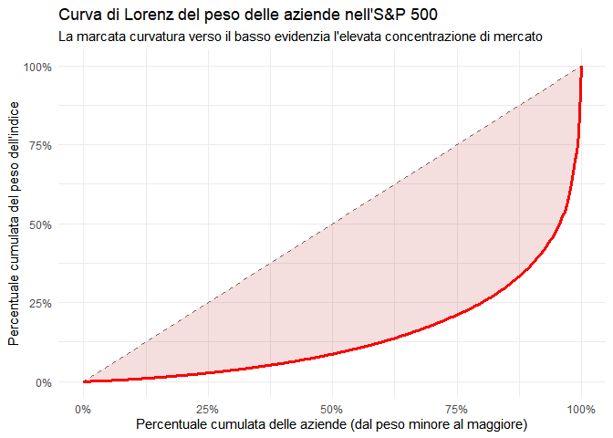

```r
library(ineq)

lorenz_obj = Lc(sp500$weight_pct)

#conversione dei dati in un df per metterli su un grafico
lorenz_df = tibble(
  p = lorenz_obj$p,
  L = lorenz_obj$L
)

ggplot(lorenz_df, aes(x = p, y = L)) +
  geom_line(color = "red", linewidth = 1.2)+
  geom_segment(aes(x = 0, y = 0, xend = 1, yend = 1), linetype = "dashed", color = "grey40") +
  geom_ribbon(aes(ymin = L, ymax = p), fill = "firebrick", alpha = 0.15) +
  scale_x_continuous(labels = scales::percent) +
  scale_y_continuous(labels = scales::percent) +
  theme_minimal() +
  labs(
    title = "Curva di Lorenz del peso delle aziende nell'S&P 500",
    subtitle = "La marcata curvatura verso il basso evidenzia l'elevata concentrazione di mercato",
    x = "Percentuale cumulata delle aziende (dal peso minore al maggiore)",
    y = "Percentuale cumulata del peso dell'indice"
)
```

### Punto 4:

*Qual’è il coefficiente di Gini dei pesi dell’S&P 500?*

Il coefficiente di Gini sintetizza in un unico numero l’area di concentrazione compresa tra la linea di perfetta uguaglianza e la curva di Lorenz (la regione rosa che vediamo nel grafico precedente), questo valore è compreso tra 0 e 1:

- *0* : Uguaglianza perfetta, quindi tutte le 500 aziende pesano esattamente lo 0.20% del totale;
- *1* : Massima concentrazione, quindi un’unica azienda detiene il 100% del peso dell’indice.

```r
gini_value = ineq(sp500$weight_pct, type = "Gini")
gini_pct = round(gini_value * 100, 2)

gini_pct
```

```
## [1] 70.92
```